# Business Statistics Mid-Term Assessment IB94X0 2023-2024 #1

5582755

2023-10-21

This is to certify that the work I am submitting is my own. All external references and sources are clearly acknowledged and identified within the contents. I am aware of the University of Warwick regulation concerning plagiarism and collusion.

No substantial part(s) of the work submitted here has also been submitted by me in other assessments for accredited courses of study, and I acknowledge that if this has been done an appropriate reduction in the mark I might otherwise have received will be made.

## Tasks

This report fulfills the request of the company, performing the specific analyses requested.

1. Children in low income homes by borough Provide a table that shows for each borough: the average number of children in low income homes per ward across all years in the dataset, the standard deviation of children in low income homes per ward across all years in the dataset, the lowest number of children in low income homes recorded for a ward in any year, and the highest number of children in low income homes recorded for a ward in any year.
2. Exclude unusual boroughs Excluding a small number of unusual boroughs. The boroughs to be excluded are: City of London; Kensington and Chelsea; Kingston upon Thames; Richmond upon Thames; Westminster.
3. Visualise data for different years Create a visualisation using either violin/Jitter plot that shows the distribution of children in low income households in wards for each year. The plot should also clearly show a visual representation of the mean value and standard deviation for each year.
4. A t-test comparing earliest and latest year Perform a t-test to compare the children in low income households in wards in the earliest year in the dataset (2014) and the latest year in the dataset (2021) and report the results using Null Hypothesis Significance Testing, and the estimation approach.

# Section 1: R code

```r
knitr::opts_chunk$set(echo = TRUE)

library(tidyverse)
options(width=100)
library(lubridate)
```

## Data Dictionary

We have been given the data on children living in low income households in London. London is split into boroughs (large areas of London which usually have their own local council or local government) and then further sub-divided into wards. This data is provided across 8 years. It shows the counts for the number of children living in low income housing within each ward in London.

| Variable | Description |
| --- | --- |
| Ward code | Unique code for each Ward |
| Wards (2018) | Name of the Ward as per year 2018 within each Borough |
| Borough | Name of the Boroughs within London |
| year | Year from which data for each ward is given (2014-2021) |
| children | children living in low income households |

## Read Data

```r
# First read in the data and check if the format for any variable needs to be converted.

children_data <- read_csv("children_low_income_data.csv")
str(children_data)
```

```
## spc_tbl_ [5,120 × 5] (S3: spec_tbl_df/tbl_df/tbl/data.frame)
##  $ Ward code   : chr [1:5120] "E05000026" "E05000026" "E05000026" "E05000026" ...
##  $ Wards (2018): chr [1:5120] "Abbey" "Abbey" "Abbey" "Abbey" ...
##  $ Borough     : chr [1:5120] "Barking and Dagenham" "Barking and Dagenham" "Barking and Dagenham" "Barking and Dagenham" ...
##  $ year        : num [1:5120] 2014 2015 2016 2017 2018 ...
##  $ children    : num [1:5120] 1090 1119 1306 1417 1466 ...
##  - attr(*, "spec")=
##   .. cols(
##   ..   `Ward code` = col_character(),
##   ..   `Wards (2018)` = col_character(),
##   ..   Borough = col_character(),
##   ..   year = col_double(),
##   ..   children = col_double()
##   .. )
##  - attr(*, "problems")=<externalptr>
```

```r
# We convert variable year from from a numeric to a factor variable.
children_data$year <- as.factor(children_data$year)
```

## Checking the Integrity of Data

Cleaning data by removing for NA values.

```r
summary(children_data)
```

```
##   Ward code         Wards (2018)         Borough               year         children
##  Length:5120        Length:5120        Length:5120        2014   : 640   Min.   :   5.0
##  Class :character   Class :character   Class :character   2015   : 640   1st Qu.: 270.0
##  Mode  :character   Mode  :character   Mode  :character   2016   : 640   Median : 511.0
##                                                           2017   : 640   Mean   : 570.1
##                                                           2018   : 640   3rd Qu.: 794.0
##                                                           2019   : 640   Max.   :2094.0
##                                                           (Other):1280   NA's   :33
```

```r
# We remove the row for which the data for children is missing.
children_data_clean <- na.omit(children_data)
```

## Visualisation of Number of Children in Low Income Household

To check for any Outliers in data.

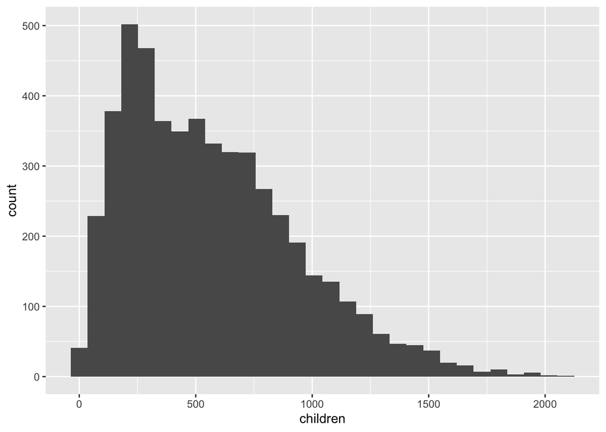

```r
ggplot(children_data_clean)+
  geom_histogram(aes(children))
```

```r
# There is a strong positive skew relation in the number of children in low income households. We will continue to apply the two sample t-tests as they are specifically requested. but t test is not appropriate for the data that is strongly non-normally distributed.
```

We do not find any extreme outliers. But we did find that the data is positively skewed.

## 1) Children in low income homes by borough

```r
boroughs_data <- children_data_clean %>%
  group_by (Borough) %>%
  summarise(frequency = n() ,mean = mean(children, na.rm = TRUE),
            standard_Deviation = sd(children, na.rm=TRUE),
            minimum_children = min(children, `Wards (2018)`,na.rm = TRUE),
            maximum_children = max(children,na.rm = TRUE),
            ward_with_min_children = `Wards (2018)`[which.min(children)],
            ward_with_max_children = `Wards (2018)`[which.max(children)])
```

## 2) Exclude unusual boroughs

```r
# We exclude the unusual boroughs from data as requested and make a new data set naming children_excl_borough.

unusual_borough <- c("City of London","Kensington and Chelsea","Kingston upon Thames","Richmond upon Thames","Westminster")
children_excl_borough <- children_data_clean %>%
  filter(!(Borough %in% unusual_borough))
```

## 3) Visualise data for different years

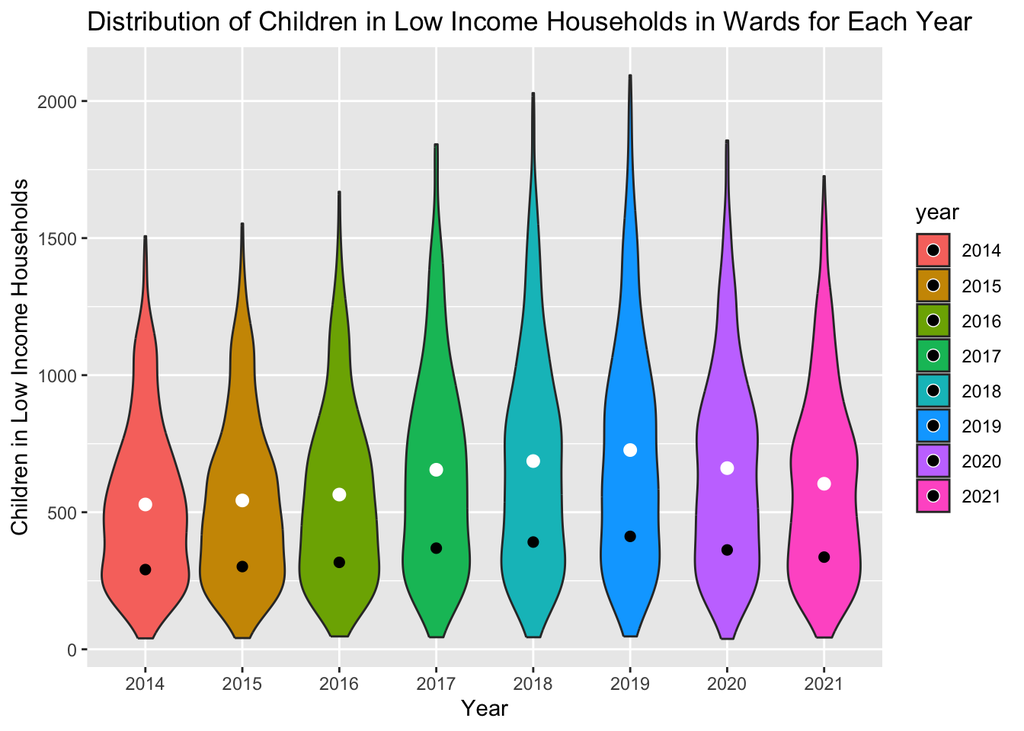

```r
ggplot(children_excl_borough, aes(x = year, y = children, fill = year)) +
  geom_violin()+
  stat_summary(fun = mean, geom ="point", color = "white", size=2.5 ) +
  stat_summary(fun = sd, geom ="point", size=2, color="black")+
  labs(title = "Distribution of Children in Low Income Households in Wards for Each Year", x="Year", y="Children in Low Income Households")
```

```r
# Black point in the plot shows the standard deviation for each year and the white points shows the mean for each year.
```

The plot shows variation in number of children in low income households over the year 2014 to 2021 in different Wards accros London. White points show the mean number of children in low income households. We can see a slight upward movement in the mean value till year 2019 and then downward movement from 2020. Black point show the standard deviation for each year and we can observe a similar pattern in it as in the mean.

```r
# This table show the numeric value of the mean and standard deviation of number children living in low income households for every year.

yearly_data <- children_excl_borough %>%
  group_by(year) %>%
  summarise( mean = mean(children),
            standard_deviation = sd(children))
```

[output not shown]

## 4) A t-test comparing earliest and latest year

### Data quality checks and visualisation of number of children in low income households in every year before performing the t-test.

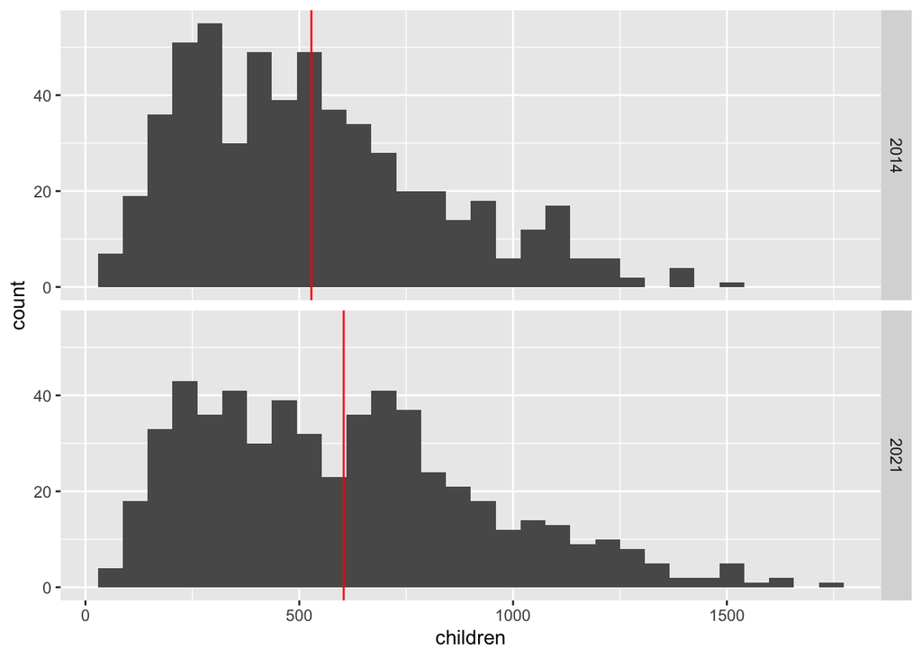

```r
children_2014_2021 <- filter(children_excl_borough,
                             year %in% c("2014", "2021"))
year_14_21 <- filter(yearly_data, year %in% c("2014","2021"))
ggplot(children_2014_2021)+
  geom_histogram(aes(children))+
  facet_grid(year~.)+
  geom_vline(data = year_14_21, mapping = aes(xintercept = mean), col = "red")
```

```r
# There is a positive skewed relation in the number of children for both the years. We will continue to apply the two sample t-tests as they are specifically requested. but t test is not appropriate for the data that is non-normally distributed.
```